# Week 1 — Exercise 2.8

Kári Hlynsson

# 1 Packages

```r
library(ISLR2)
library(tidyverse)
library(magrittr)
library(GGally)
library(gridExtra)

theme_set(theme_classic())
```

# 2 Description of data set

Contained in this document is my solution of Exercise 2.8 from *An Introduction to Statistical Learning*. In this exercise, the data set `College` is used, which contains a number of variables for 777 different universities and colleges in the US. The variables in the data as well as a short description is shown below in Table 2.1.

Table 2.1: Description of the `College` data set.

| Variable | Description |
| --- | --- |
| `Private` | Public / private indicator |
| `Apps` | Number of applications received |
| `Accept` | Number of applicants accepted |
| `Enroll` | Number of new students enrolled |
| `Top10perc` | New students from top 10 % of high school class |
| `Top25perc` | New students from top 25 % of high school class |
| `F.Undergrad` | Number of full-time undergraduates |
| `P.Undergrad` | Number of part-time undergraduates |
| `Outstate` | Out-of-state tuition |
| `Room.Board` | Room and board costs |
| `Books` | Estimated book costs |
| `Personal` | Estimated personal spending |
| `PhD` | Percent of faculty with Ph.D.’s |
| `Terminal` | Percent of faculty with terminal degree |
| `S.F.Ratio` | Student/faculty ratio |
| `perc.alumni` | Percent of alumni who donate |
| `Expend` | Instructional expenditure per student |
| `Grad.Rate` | Graduation rate |

# 3 Exploring the data

Start by importing the data set using the `data` command. This is possible since the `ISLR2` package has been installed. The row names in the data set are already configured to be the names of the universities and colleges, so there is no need to make changes to that part.

```r
# Load the data set
data(College)

# Look at data types
glimpse(College)
```

```
## Rows: 777
## Columns: 18
## $ Private     <fct> Yes, Yes, Yes, Yes, Yes, Yes, Yes, Yes, Yes, Yes, Yes, Yes…
## $ Apps        <dbl> 1660, 2186, 1428, 417, 193, 587, 353, 1899, 1038, 582, 173…
## $ Accept      <dbl> 1232, 1924, 1097, 349, 146, 479, 340, 1720, 839, 498, 1425…
## $ Enroll      <dbl> 721, 512, 336, 137, 55, 158, 103, 489, 227, 172, 472, 484,…
## $ Top10perc   <dbl> 23, 16, 22, 60, 16, 38, 17, 37, 30, 21, 37, 44, 38, 44, 23…
## $ Top25perc   <dbl> 52, 29, 50, 89, 44, 62, 45, 68, 63, 44, 75, 77, 64, 73, 46…
## $ F.Undergrad <dbl> 2885, 2683, 1036, 510, 249, 678, 416, 1594, 973, 799, 1830…
## $ P.Undergrad <dbl> 537, 1227, 99, 63, 869, 41, 230, 32, 306, 78, 110, 44, 638…
## $ Outstate    <dbl> 7440, 12280, 11250, 12960, 7560, 13500, 13290, 13868, 1559…
## $ Room.Board  <dbl> 3300, 6450, 3750, 5450, 4120, 3335, 5720, 4826, 4400, 3380…
## $ Books       <dbl> 450, 750, 400, 450, 800, 500, 500, 450, 300, 660, 500, 400…
## $ Personal    <dbl> 2200, 1500, 1165, 875, 1500, 675, 1500, 850, 500, 1800, 60…
## $ PhD         <dbl> 70, 29, 53, 92, 76, 67, 90, 89, 79, 40, 82, 73, 60, 79, 36…
## $ Terminal    <dbl> 78, 30, 66, 97, 72, 73, 93, 100, 84, 41, 88, 91, 84, 87, 6…
## $ S.F.Ratio   <dbl> 18.1, 12.2, 12.9, 7.7, 11.9, 9.4, 11.5, 13.7, 11.3, 11.5, …
## $ perc.alumni <dbl> 12, 16, 30, 37, 2, 11, 26, 37, 23, 15, 31, 41, 21, 32, 26,…
## $ Expend      <dbl> 7041, 10527, 8735, 19016, 10922, 9727, 8861, 11487, 11644,…
## $ Grad.Rate   <dbl> 60, 56, 54, 59, 15, 55, 63, 73, 80, 52, 73, 76, 74, 68, 55…
```

The data set consists of 777 observations with 18 features per observation. All the variables are numeric except for `Private`, which is a factor (binary) variable. There is no change necessary here. Let us summarise the variables:

```r
summary(College)
```

```
##  Private        Apps           Accept          Enroll       Top10perc
##  No :212   Min.   :   81   Min.   :   72   Min.   :  35   Min.   : 1.00
##  Yes:565   1st Qu.:  776   1st Qu.:  604   1st Qu.: 242   1st Qu.:15.00
##            Median : 1558   Median : 1110   Median : 434   Median :23.00
##            Mean   : 3002   Mean   : 2019   Mean   : 780   Mean   :27.56
##            3rd Qu.: 3624   3rd Qu.: 2424   3rd Qu.: 902   3rd Qu.:35.00
##            Max.   :48094   Max.   :26330   Max.   :6392   Max.   :96.00
##    Top25perc      F.Undergrad     P.Undergrad         Outstate
##  Min.   :  9.0   Min.   :  139   Min.   :    1.0   Min.   : 2340
##  1st Qu.: 41.0   1st Qu.:  992   1st Qu.:   95.0   1st Qu.: 7320
##  Median : 54.0   Median : 1707   Median :  353.0   Median : 9990
##  Mean   : 55.8   Mean   : 3700   Mean   :  855.3   Mean   :10441
##  3rd Qu.: 69.0   3rd Qu.: 4005   3rd Qu.:  967.0   3rd Qu.:12925
##  Max.   :100.0   Max.   :31643   Max.   :21836.0   Max.   :21700
##    Room.Board       Books           Personal         PhD
##  Min.   :1780   Min.   :  96.0   Min.   : 250   Min.   :  8.00
##  1st Qu.:3597   1st Qu.: 470.0   1st Qu.: 850   1st Qu.: 62.00
##  Median :4200   Median : 500.0   Median :1200   Median : 75.00
##  Mean   :4358   Mean   : 549.4   Mean   :1341   Mean   : 72.66
##  3rd Qu.:5050   3rd Qu.: 600.0   3rd Qu.:1700   3rd Qu.: 85.00
##  Max.   :8124   Max.   :2340.0   Max.   :6800   Max.   :103.00
##     Terminal       S.F.Ratio      perc.alumni        Expend
##  Min.   : 24.0   Min.   : 2.50   Min.   : 0.00   Min.   : 3186
##  1st Qu.: 71.0   1st Qu.:11.50   1st Qu.:13.00   1st Qu.: 6751
##  Median : 82.0   Median :13.60   Median :21.00   Median : 8377
##  Mean   : 79.7   Mean   :14.09   Mean   :22.74   Mean   : 9660
##  3rd Qu.: 92.0   3rd Qu.:16.50   3rd Qu.:31.00   3rd Qu.:10830
##  Max.   :100.0   Max.   :39.80   Max.   :64.00   Max.   :56233
##    Grad.Rate
##  Min.   : 10.00
##  1st Qu.: 53.00
##  Median : 65.00
##  Mean   : 65.46
##  3rd Qu.: 78.00
##  Max.   :118.00
```

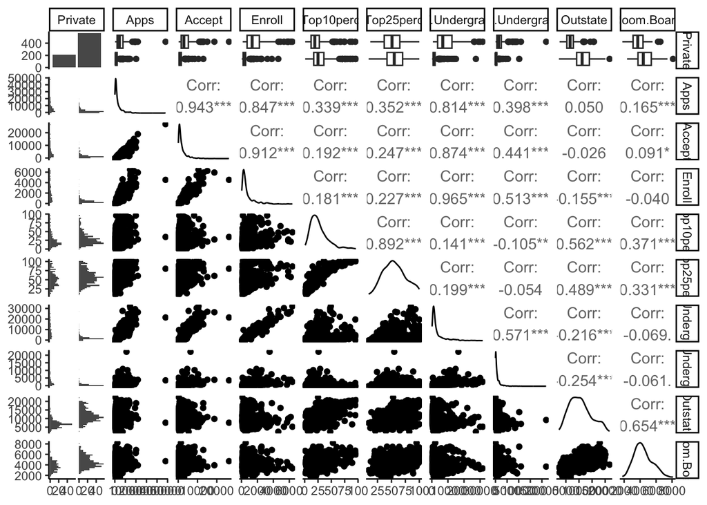

```r
ggpairs(College[,1:10])
```

Side by side boxplots of `Outstate` versus `Private`:

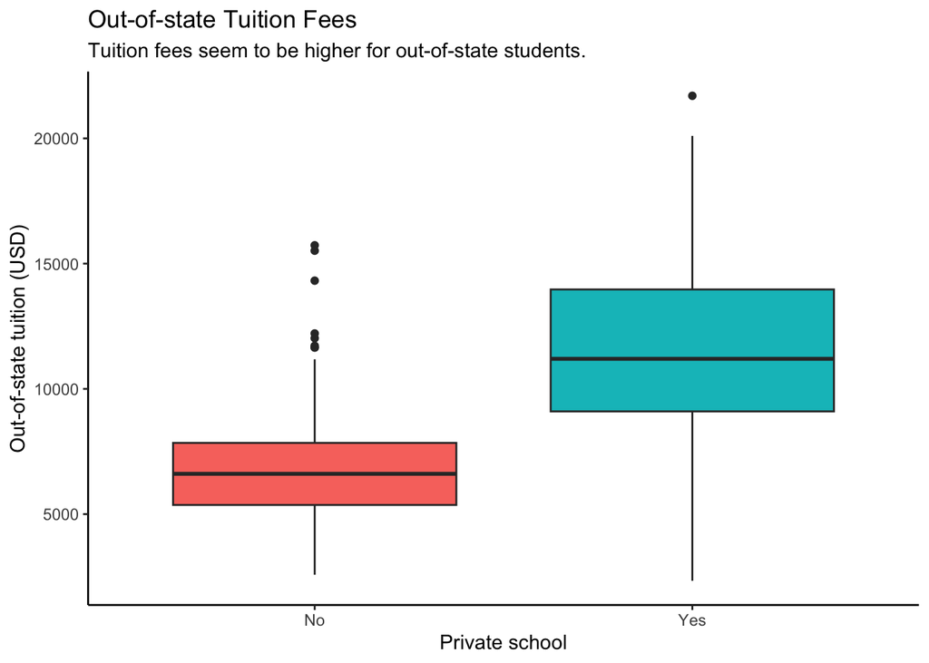

```r
ggplot(College, aes(x = Private, y = Outstate, fill = Private)) +
  geom_boxplot() +
  theme(legend.position = "none") +
  labs(
    title = "Out-of-state Tuition Fees",
    subtitle = "Tuition fees seem to be higher for out-of-state students.",
    y = "Out-of-state tuition (USD)",
    x = "Private school"
  )
```

Create the `Elite` variable:

```r
College %<>% mutate(Elite = factor(ifelse(College$Top10perc > 50, "Yes", "No")))
```

Let’s look at how many of the universities fall under the elite category:

```r
College %>% count(Elite)
```

```
##   Elite   n
## 1    No 699
## 2   Yes  78
```

78 of the 777 colleges and universities, or about 10% fall under the elite category. This is quite satisfying. We might also be interested in seeing which of the universities have the highest percentage of elite students from their respective high schools:

```r
College %>%
  filter(Elite == "Yes") %>%
  arrange(desc(Top10perc)) %>%
  select(Private, Apps, Accept, Enroll, Top10perc) %>%
  head(10) %>%
  knitr::kable(caption = "Top 10 universities in terms of elite student percentage.")
```

Table 3.1: Top 10 universities in terms of elite student percentage.

|  | Private | Apps | Accept | Enroll | Top10perc |
| --- | --- | --- | --- | --- | --- |
| Massachusetts Institute of Technology | Yes | 6411 | 2140 | 1078 | 96 |
| Harvey Mudd College | Yes | 1377 | 572 | 178 | 95 |
| University of California at Berkeley | No | 19873 | 8252 | 3215 | 95 |
| Yale University | Yes | 10705 | 2453 | 1317 | 95 |
| Duke University | Yes | 13789 | 3893 | 1583 | 90 |
| Harvard University | Yes | 13865 | 2165 | 1606 | 90 |
| Princeton University | Yes | 13218 | 2042 | 1153 | 90 |
| Georgia Institute of Technology | No | 7837 | 4527 | 2276 | 89 |
| Brown University | Yes | 12586 | 3239 | 1462 | 87 |
| Dartmouth College | Yes | 8587 | 2273 | 1087 | 87 |

These names are certainly not unfamiliar, at least not to an undergraduate student. Let us next create some histograms of a selection of the quantitative variables.

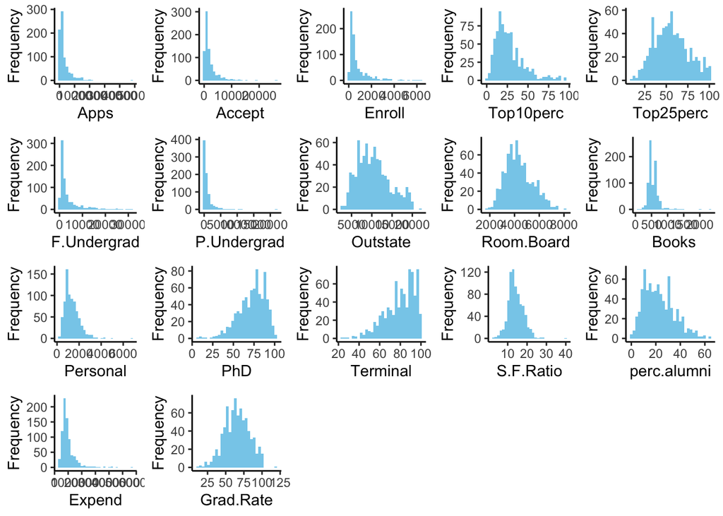

Figure 3.1: Histograms of quantitative variables in the data set.

```r
hist_fn <- function(data) {
  grob <- ggplot(College, aes(x = get(data))) +
    geom_histogram(fill = "skyblue") +
    labs(x = paste(data), y = "Frequency")
  return(grob)
}

grobs <- College %>% select_if(is.numeric) %>% colnames() %>% lapply(hist_fn)

grid.arrange(grobs = grobs, nrow = 4)
```